# Crime Analytics: Visualization of Incident Reports

CA

November 2018

# Intro

In the following, we will examine if the time and weekday makes a difference in the number of crimes in both, San Francisco and Seattle. After that we will take a look into effects of temperature and weather on the crimes.

```r
library(tidyverse)
library(lubridate)
library(gridExtra)

SEA <- read_csv("seattle_incidents_summer_2014.csv") %>%
  mutate(datetime = mdy_hms(`Occurred Date or Date Range Start`)) %>%
  mutate(hourdate = paste0(as.Date(datetime), hour(datetime), ":00:00") %>% ymd_hms)


SFO <- read_csv("sanfrancisco_incidents_summer_2014.csv") %>%
  mutate(datetime = paste0(Date, " ", Time) %>% mdy_hms) %>%
  mutate(hourdate = paste0(as.Date(datetime), hour(datetime), ":00:00") %>% ymd_hms)

# Inspect data
library(darksky)
darksky_api_key()

locations <- data.frame(loc = c("San Francisco", "Seattle"),
                        lat = c(37.7577, 47.602783),
                        lon = c(-122.4727, -122.31784))
dates <- seq.POSIXt(from = ymd("14-6-1", tz = "America/Los_Angeles"),
                    to = ymd("14-8-31", tz = "America/Los_Angeles"),
                    by = "day")

library(purrr)

# Uncomment for API calls, using cached data here

# SFOweather <- dates %>%
#   map(~get_forecast_for(locations$lat[1], locations$lon[1], .x)) %>%
#   map_df("hourly") %>%
#   mutate(time = with_tz(time, tzone = "America/Los_Angeles"))

SFOweather <- readRDS("SFOW.RDS")

# SEAweather <- dates %>%
#   map(~get_forecast_for(locations$lat[2], locations$lon[2], .x)) %>%
#   map_df("hourly")

SEAweather <- readRDS("SEAW.RDS")

# Merge Data

xSEA <- inner_join(SEA, SEAweather, by = c("hourdate" = "time"))
xSFO <- inner_join(SFO, SFOweather, by = c("hourdate" = "time"))


# Population 2014
SFOpop <- 853258
SEApop <- 669641

#ggplot(SFOweather, aes(time, temperature)) + geom_line()
```

# Hour and Day of crimes occuring

The figure belows shows a heat map of crimes with respect to the hour of the day and the day of the week. The following interesting patterns can be derived:

- Most crimes occur in the afternoon in both cities, with SFO having a high concentration between 4pm to 6pm.
- The least crime happens in the night hours between midnight and 6am in both cities.
- In both cities, more crimes happen on Saturday and Sunday morning between 1am and 3am than during weekdays (which makes sense),
- whereas Saturday and Sunday mornings crimes are less frequent than during weekdays.

We can conclude, that crime “stays out late but sleeps in on weekends”.

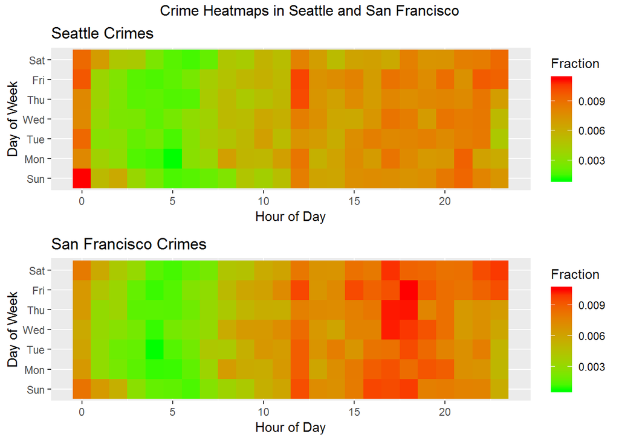

```r
a <- SEA %>% group_by(hour = mdy_hms(`Occurred Date or Date Range Start`) %>% hour, day = mdy_hms(`Occurred Date or Date Range Start`) %>% wday(label = T)) %>%
  summarize(n = n()/nrow(SEA)) %>%
  ggplot(aes(hour, day, fill = n)) +
  geom_tile() +
  scale_fill_gradient(low = "green", high = "red", name = "Fraction", breaks = c(.003,.006,.009)) +
  labs(title = "Seattle Crimes", x = "Hour of Day", y = "Day of Week")

b <- SFO %>% group_by(hour = ymd_hms(hourdate) %>% hour, day = ymd_hms(hourdate) %>% wday(label = T)) %>%
  summarize(n = n()/nrow(SFO)) %>%
  ggplot(aes(hour, day, fill = n)) +
  geom_tile() +
  scale_fill_gradient(low = "green", high = "red", name = "Fraction", breaks = c(.003,.006,.009)) +
  labs(title = "San Francisco Crimes", x = "Hour of Day", y = "Day of Week")

grid.arrange(a,b, top = "Crime Heatmaps in Seattle and San Francisco")
```

# Crime vs. Temperature

In the follwing, we want to find out if the number of crimes and the average daily temperature are correlated. Only a graphical analysis is done herein and no quantitative analysis is conducted. The weather data was sources from [DarkSky](https://darksky.net/dev) for the data period in question.

For both cities, the correlation appears to be rather weak and anecdotal. This is likely due to limited data and very shallow analysis herein. [Scientific studies](https://www.ncbi.nlm.nih.gov/pubmed/1271212) point to a high correlation between aggression and temperature (+ humidity). This would be an interesting topic for another data science exercise.

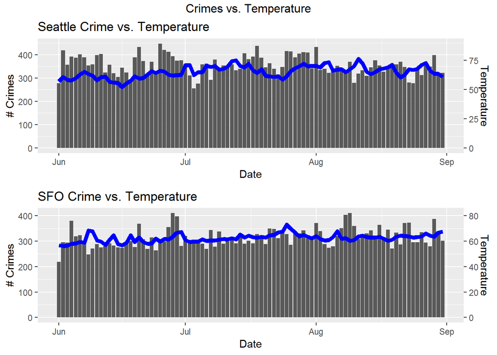

```r
c <- xSEA %>% group_by(day = mdy_hms(`Occurred Date or Date Range Start`) %>% as.Date) %>%
  summarize(n = n(), avgT = mean(temperature), avgH = mean(humidity)) %>%
  ggplot(aes(day, n)) +
  geom_bar(stat = "identity") +
  geom_line(aes(day, avgT*5), col = "blue", size = 2) +
  scale_y_continuous(name = "# Crimes", sec.axis = sec_axis(~ . /5, name = "Temperature")) +
  labs(title = "Seattle Crime vs. Temperature", x = "Date")

d <- xSFO %>% group_by(day = ymd_hms(hourdate) %>% as.Date) %>%
  summarize(n = n(), avgT = mean(temperature), avgH = mean(humidity)) %>%
  ggplot(aes(day, n)) +
  geom_bar(stat = "identity") +
  geom_line(aes(day, avgT*5), col = "blue", size = 2) +
  scale_y_continuous(name = "# Crimes", sec.axis = sec_axis(~ . /5, name = "Temperature")) +
  labs(title = "SFO Crime vs. Temperature", x = "Date")

grid.arrange(c, d, top = "Crimes vs. Temperature")
```

# Crimes vs. Weather Change

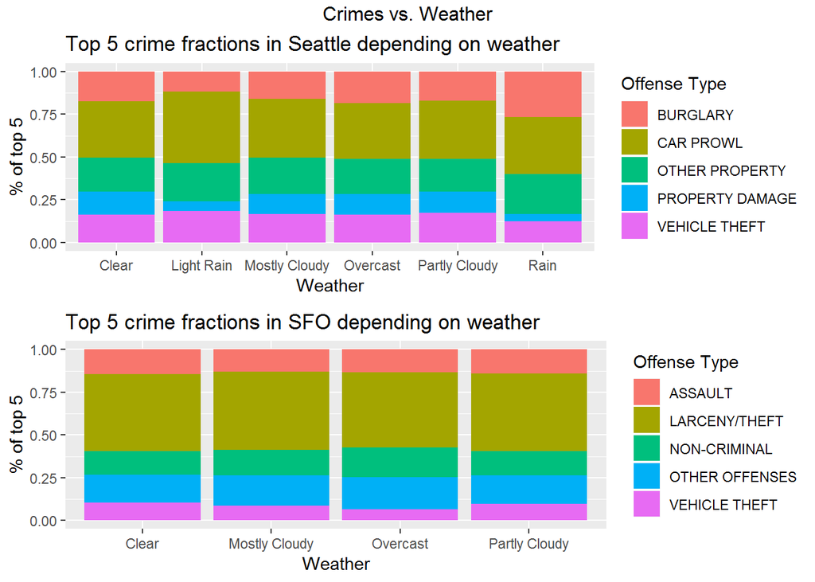

```r
#SEA
top10 <- xSEA %>% group_by(offense = `Summarized Offense Description`) %>%
  summarize(n = n()) %>%
  top_n(5, n)

perc <- xSEA %>% filter(`Summarized Offense Description` %in% top10$offense) %>%
  group_by(summary) %>%
  summarize(buck = n())

e <- xSEA %>% filter(`Summarized Offense Description` %in% top10$offense) %>%
  group_by(offense = `Summarized Offense Description`, summary) %>%
  summarize(n = n()) %>%
  inner_join(perc, by = "summary") %>%
  mutate(ratio = n/buck) %>%
  arrange(desc(buck)) %>%
  ggplot(aes(summary, ratio, fill = offense)) + geom_bar(stat = "identity") +
  labs(title = "Top 5 crime fractions in Seattle depending on weather", x = "Weather", y = "% of top 5", fill = "Offense Type")

#SFO
top10 <- xSFO %>% group_by(offense = Category) %>%
  summarize(n = n()) %>%
  top_n(5, n)

perc <- xSFO %>% filter(Category %in% top10$offense) %>%
  group_by(summary) %>%
  summarize(buck = n())

f <- xSFO %>% filter(Category %in% top10$offense) %>%
  group_by(offense = Category, summary) %>%
  summarize(n = n()) %>%
  inner_join(perc, by = "summary") %>%
  mutate(ratio = n/buck) %>%
  arrange(desc(buck)) %>%
  ggplot(aes(summary, ratio, fill = offense)) + geom_bar(stat = "identity") +
  labs(title = "Top 5 crime fractions in SFO depending on weather", x = "Weather", y = "% of top 5", fill = "Offense Type")

grid.arrange(e, f, top = "Crimes vs. Weather")
```

# Summary and Conclusion

All findings herein are anecotal as the main objective of this excercise was visualization and not deep analysis. However, the analysis shows the possibility to merge various data sources and exploit APIs for deep analysis of social phenomena - and gives the reader ideas for future analysis!

Happy coding!